# initial_survey

## tariff

| Feature | Result |
| --- | --- |
| Variable type | character |
| Number of missing obs. | 0 (0 %) |
| Number of unique values | 4 |
| Mode | “” |

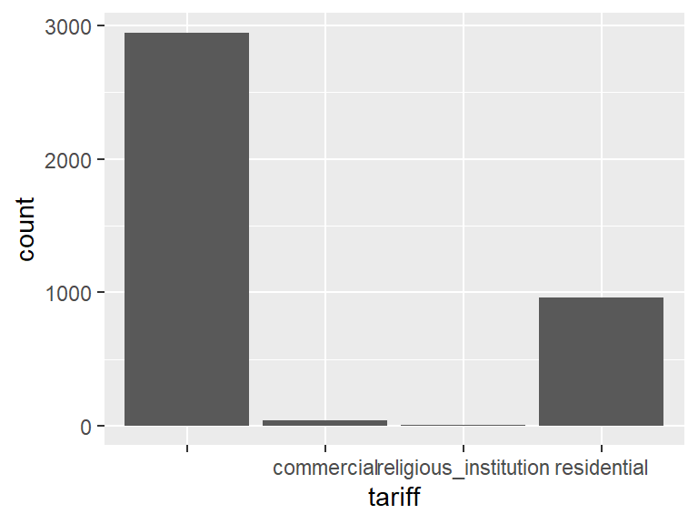

- The following suspected missing value codes enter as regular values: "".
- Note that the following levels have at most five observations: "religious_institution".

## occupation_secondary_provider

| Feature | Result |
| --- | --- |
| Variable type | character |
| Number of missing obs. | 0 (0 %) |
| Number of unique values | 20 |
| Mode | “” |

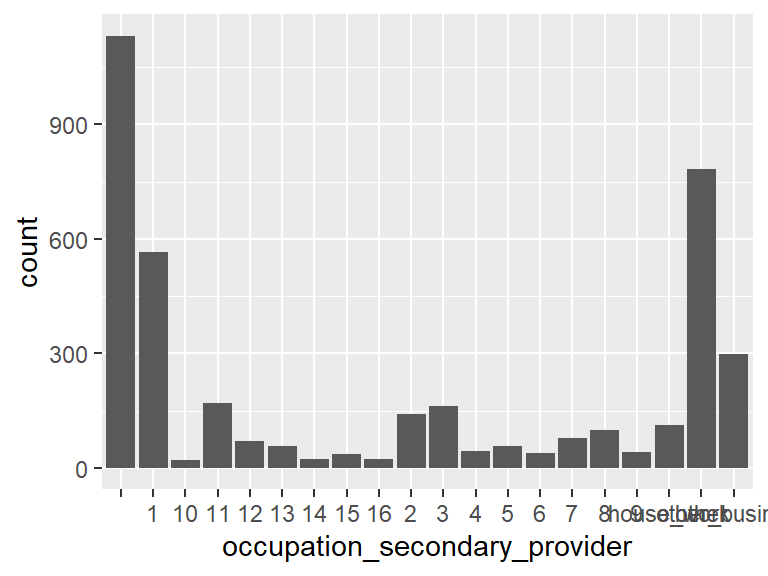

- The following suspected missing value codes enter as regular values: "", "8", "9".

## community_clean_water_source

| Feature | Result |
| --- | --- |
| Variable type | character |
| Number of missing obs. | 0 (0 %) |
| Number of unique values | 80 |
| Mode | “” |

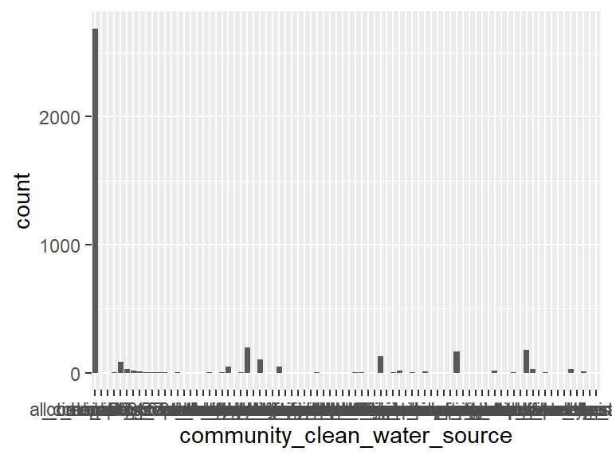

- The following suspected missing value codes enter as regular values: "", "8".
- Note that the following levels have at most five observations: "_borehole", "_community_tap", "0", "5", "7", …, "water_from_the_tape", "water_taps", "wells", "yap", "yes" (49 values omitted).

## business_owners_count

- Note that this variable is treated as a factor variable below, as it only takes a few unique values.

| Feature | Result |
| --- | --- |
| Variable type | integer |
| Number of missing obs. | 0 (0 %) |
| Number of unique values | 3 |
| Mode | “1” |
| Reference category | 0 |

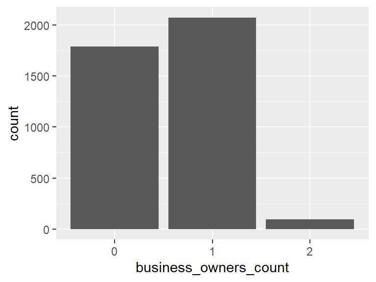

## business_owners_female

- Note that this variable is treated as a factor variable below, as it only takes a few unique values.

| Feature | Result |
| --- | --- |
| Variable type | integer |
| Number of missing obs. | 0 (0 %) |
| Number of unique values | 2 |
| Mode | “0” |
| Reference category | 0 |

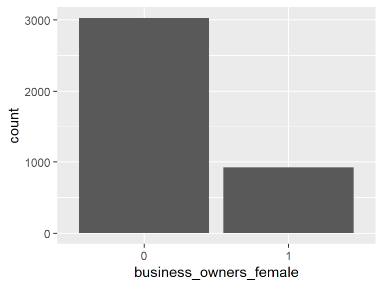

## appliances_type_count

| Feature | Result |
| --- | --- |
| Variable type | integer |
| Number of missing obs. | 0 (0 %) |
| Number of unique values | 9 |
| Median | 2 |
| 1st and 3rd quartiles | 1; 3 |
| Min. and max. | 1; 9 |

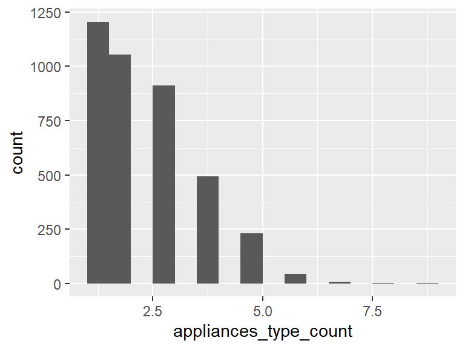

Report generation information:

- Created by: Akoua Orsot~ (username: `User`).
- Report creation time: Fri Oct 06 2023 09:11:11
- Report was run from directory: `\\wsl.localhost/Ubuntu/home/aorsot/Renewvia/survey_impact_analysis`
- dataMaid v1.4.1 [Pkg: 2021-10-08 from CRAN (R 4.3.1)]
- R version 4.3.1 (2023-06-16 ucrt).
- Platform: x86_64-w64-mingw32/x64 (64-bit)(Etc/UTC).
- Function call: `makeDataReport(data = initial_survey, output = "html", replace = TRUE)`